# Project-1: Building Convolutional Neural Networks on MNIST Dataset

### thevivekai@gmail.com

**Learning Objectives**

- Understand CNN architecture and its components
- Implement CNN from scratch using TensorFlow/Keras
- Master data preprocessing for image classification
- Compare different CNN architectures

**Dataset Information**

- 70,000 grayscale images of handwritten digits (0-9)
- Training set: 60,000 images
- Test set: 10,000 images
- Image dimensions: 28x28 pixels
- 10 classes (digits 0-9)

### Step-1: Import the Required Libraries

```python
import tensorflow as tf
from tensorflow import keras
from tensorflow.keras.models import Sequential
from tensorflow.keras.layers import Conv2D,MaxPooling2D,Flatten,Dense,Dropout
from tensorflow.keras.optimizers import Adam
from tensorflow.keras.utils import to_categorical
import numpy as np
import matplotlib.pyplot as plt
import seaborn as sns
from sklearn.metrics import classification_report,confusion_matrix
import pandas as pd
```

### Step-2: Data Loading and Pre Processing

#### 2.1 Data Loading & Exploration

```python
# Here we Load the MNIST dataset using tf.keras.datasets.mnist.load_data()
(x_train,y_train),(x_test,y_test)=tf.keras.datasets.mnist.load_data()
```

```python
# Here we Display the shape of training and testing sets
x_train.shape,x_test.shape,y_train.shape,y_test.shape
```

```
((60000, 28, 28), (10000, 28, 28), (60000,), (10000,))
```

```python
# One Hot Encode Label
y_train_cat=to_categorical(y_train,10)
y_test_cat=to_categorical(y_test,10)
```

#### 2.2 Data Pre-processing

- First we normalize the data with in a range by which all value come in a certain range
- Then we reshaping the image to add channel dimension(28,28,1)

```python
# Normalization
x_train,x_test=x_train/255.0,x_test/255.0
```

```python
# Reshaping
x_train = np.expand_dims(x_train, -1)
x_test = np.expand_dims(x_test, -1)
```

### Step-3: Building Basic CNN Architecture

#### 3.1 Design CNN Architecture:

```python
model = Sequential()
model.add(Conv2D(32,(3,3),activation='relu',input_shape=[28,28,1],padding='same'))
model.add(MaxPooling2D((2,2)))
model.add(Conv2D(64,(3,3),activation='relu'))
model.add(MaxPooling2D((2,2)))
model.add(Conv2D(64,(3,3),activation='relu'))
model.add(Flatten())
model.add(Dense(64,activation='relu'))
model.add(Dense(10,activation='softmax'))
```

```python
model.summary()
```

```
Model: "sequential_3"
```

```
┏━━━━━━━━━━━━━━━━━━━━━━━━━━━━━━━━━┳━━━━━━━━━━━━━━━━━━━━━━━━┳━━━━━━━━━━━━━━━┓
┃ Layer (type)                    ┃ Output Shape           ┃       Param # ┃
┡━━━━━━━━━━━━━━━━━━━━━━━━━━━━━━━━━╇━━━━━━━━━━━━━━━━━━━━━━━━╇━━━━━━━━━━━━━━━┩
│ conv2d_9 (Conv2D)               │ (None, 28, 28, 32)     │           320 │
├─────────────────────────────────┼────────────────────────┼───────────────┤
│ max_pooling2d_6 (MaxPooling2D)  │ (None, 14, 14, 32)     │             0 │
├─────────────────────────────────┼────────────────────────┼───────────────┤
│ conv2d_10 (Conv2D)              │ (None, 12, 12, 64)     │        18,496 │
├─────────────────────────────────┼────────────────────────┼───────────────┤
│ max_pooling2d_7 (MaxPooling2D)  │ (None, 6, 6, 64)       │             0 │
├─────────────────────────────────┼────────────────────────┼───────────────┤
│ conv2d_11 (Conv2D)              │ (None, 4, 4, 64)       │        36,928 │
├─────────────────────────────────┼────────────────────────┼───────────────┤
│ flatten_3 (Flatten)             │ (None, 1024)           │             0 │
├─────────────────────────────────┼────────────────────────┼───────────────┤
│ dense_6 (Dense)                 │ (None, 64)             │        65,600 │
├─────────────────────────────────┼────────────────────────┼───────────────┤
│ dense_7 (Dense)                 │ (None, 10)             │           650 │
└─────────────────────────────────┴────────────────────────┴───────────────┘
```

```
 Total params: 121,994 (476.54 KB)
```

```
 Trainable params: 121,994 (476.54 KB)
```

```
 Non-trainable params: 0 (0.00 B)
```

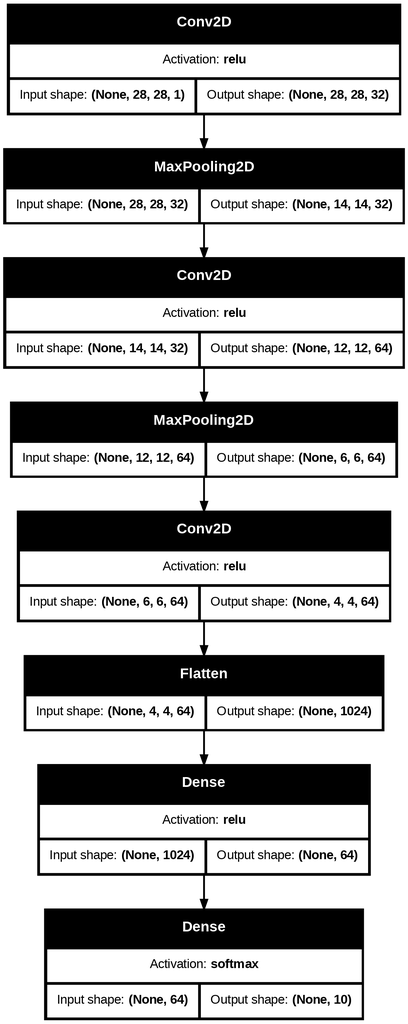

```python
tf.keras.utils.plot_model(model,to_file='model_architecture.png',show_shapes=True,show_layer_activations=True)
```

#### 3.2 Model Compilation

```python
model.compile(optimizer=Adam(learning_rate=0.001),loss='categorical_crossentropy',metrics=['accuracy'])
```

### Step-4: Model Training & Evaluation

#### 4.1 Model Training

```python
mnist_model= model.fit(x_train,y_train_cat,batch_size=128,epochs=20,validation_data=(x_test, y_test_cat))
```

```
469/469 ━━━━━━━━━━━━━━━━━━━━ 7s 10ms/step - accuracy: 0.8394 - loss: 0.5409 - val_accuracy: 0.9824 - val_loss: 0.0569
469/469 ━━━━━━━━━━━━━━━━━━━━ 2s 5ms/step - accuracy: 0.9853 - loss: 0.0506 - val_accuracy: 0.9868 - val_loss: 0.0377
469/469 ━━━━━━━━━━━━━━━━━━━━ 2s 4ms/step - accuracy: 0.9881 - loss: 0.0365 - val_accuracy: 0.9896 - val_loss: 0.0319
469/469 ━━━━━━━━━━━━━━━━━━━━ 2s 4ms/step - accuracy: 0.9921 - loss: 0.0267 - val_accuracy: 0.9919 - val_loss: 0.0277
469/469 ━━━━━━━━━━━━━━━━━━━━ 2s 4ms/step - accuracy: 0.9930 - loss: 0.0210 - val_accuracy: 0.9909 - val_loss: 0.0282
469/469 ━━━━━━━━━━━━━━━━━━━━ 2s 5ms/step - accuracy: 0.9950 - loss: 0.0162 - val_accuracy: 0.9911 - val_loss: 0.0282
469/469 ━━━━━━━━━━━━━━━━━━━━ 2s 4ms/step - accuracy: 0.9953 - loss: 0.0145 - val_accuracy: 0.9917 - val_loss: 0.0320
469/469 ━━━━━━━━━━━━━━━━━━━━ 2s 4ms/step - accuracy: 0.9963 - loss: 0.0128 - val_accuracy: 0.9916 - val_loss: 0.0280
469/469 ━━━━━━━━━━━━━━━━━━━━ 2s 4ms/step - accuracy: 0.9970 - loss: 0.0102 - val_accuracy: 0.9888 - val_loss: 0.0389
469/469 ━━━━━━━━━━━━━━━━━━━━ 2s 4ms/step - accuracy: 0.9971 - loss: 0.0086 - val_accuracy: 0.9903 - val_loss: 0.0346
469/469 ━━━━━━━━━━━━━━━━━━━━ 2s 5ms/step - accuracy: 0.9971 - loss: 0.0087 - val_accuracy: 0.9897 - val_loss: 0.0386
469/469 ━━━━━━━━━━━━━━━━━━━━ 3s 6ms/step - accuracy: 0.9972 - loss: 0.0087 - val_accuracy: 0.9910 - val_loss: 0.0346
469/469 ━━━━━━━━━━━━━━━━━━━━ 3s 6ms/step - accuracy: 0.9979 - loss: 0.0058 - val_accuracy: 0.9934 - val_loss: 0.0285
469/469 ━━━━━━━━━━━━━━━━━━━━ 2s 5ms/step - accuracy: 0.9981 - loss: 0.0056 - val_accuracy: 0.9929 - val_loss: 0.0271
469/469 ━━━━━━━━━━━━━━━━━━━━ 2s 5ms/step - accuracy: 0.9981 - loss: 0.0054 - val_accuracy: 0.9918 - val_loss: 0.0320
469/469 ━━━━━━━━━━━━━━━━━━━━ 2s 5ms/step - accuracy: 0.9984 - loss: 0.0051 - val_accuracy: 0.9924 - val_loss: 0.0353
469/469 ━━━━━━━━━━━━━━━━━━━━ 2s 5ms/step - accuracy: 0.9981 - loss: 0.0056 - val_accuracy: 0.9928 - val_loss: 0.0323
469/469 ━━━━━━━━━━━━━━━━━━━━ 2s 4ms/step - accuracy: 0.9989 - loss: 0.0033 - val_accuracy: 0.9923 - val_loss: 0.0377
469/469 ━━━━━━━━━━━━━━━━━━━━ 2s 4ms/step - accuracy: 0.9988 - loss: 0.0039 - val_accuracy: 0.9916 - val_loss: 0.0363
469/469 ━━━━━━━━━━━━━━━━━━━━ 2s 4ms/step - accuracy: 0.9989 - loss: 0.0029 - val_accuracy: 0.9931 - val_loss: 0.0353
```

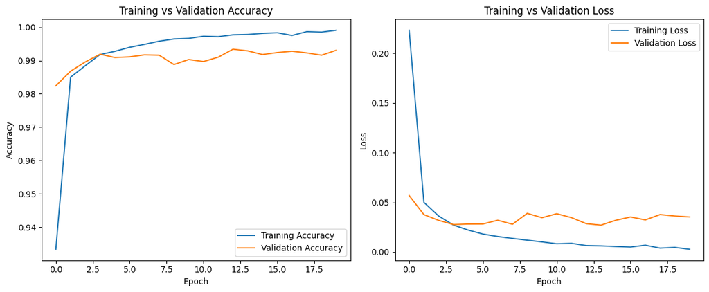

```python
# Plot training history:

plt.figure(figsize=(12, 5))

# Plotting the accuracy
plt.subplot(1, 2, 1)
plt.plot(mnist_model.history['accuracy'], label='Training Accuracy')
plt.plot(mnist_model.history['val_accuracy'], label='Validation Accuracy')
plt.title('Training vs Validation Accuracy')
plt.xlabel('Epoch')
plt.ylabel('Accuracy')
plt.legend()

# Plotting the loss
plt.subplot(1, 2, 2)
plt.plot(mnist_model.history['loss'], label='Training Loss')
plt.plot(mnist_model.history['val_loss'], label='Validation Loss')
plt.title('Training vs Validation Loss')
plt.xlabel('Epoch')
plt.ylabel('Loss')
plt.legend()

plt.tight_layout()
plt.show()
```